# Probabilistic Forecast Reconciliation Simulation

Sanghyun Kim

2025-10-01

# 1 Data preparation

In this exercise, we’ll be using a toy dataset to get the hang of how forecast reconciliation works in practice.

```r
# install.packages("tsibble")
library(tsibble)
# install.packages("tsibbledata")
library(tsibbledata) # for the aus_retail dataset
library(dplyr)
library(ggplot2)
library(lubridate)
library(fable)
library(fabletools)

glimpse(aus_retail)
```

```
## Rows: 64,532
## Columns: 5
## Key: State, Industry [152]
## $ State       <chr> "Australian Capital Territory", "Australian Capital Territ…
## $ Industry    <chr> "Cafes, restaurants and catering services", "Cafes, restau…
## $ `Series ID` <chr> "A3349849A", "A3349849A", "A3349849A", "A3349849A", "A3349…
## $ Month       <mth> 1982 Apr, 1982 May, 1982 Jun, 1982 Jul, 1982 Aug, 1982 Sep…
## $ Turnover    <dbl> 4.4, 3.4, 3.6, 4.0, 3.6, 4.2, 4.8, 5.4, 6.9, 3.8, 4.2, 4.0…
```

```r
data = aus_retail %>%
  filter(Month >= yearmonth("2015 Jan")) %>%
  as_tsibble(key = c(State, Industry), index = Month) # convert the dataframe to tsibble for time series analsis
```

This data set is not hierarchical time series, so we’ll construct a hierarchy using `State` and `Industry` in the data.

```r
retail_hier = data %>%
  aggregate_key(State/Industry, Turnover = sum(Turnover))
```

# 2 Base (incoherent) forecast generation

To generate base (incoherent) forecasts, we’ll use the ETS time series model for the purposes of demonstration. ETS generally gives non-flat, sensible forecasts. Before building the model, let’s split the data into training and test data to prevent overfitting. We’ll use the last 18 months as test data.

```r
n_test = 18

# define the cutoff
cutoff = max(retail_hier$Month) - n_test

train_data = retail_hier %>% filter(Month <= cutoff)
test_data  = retail_hier %>% filter(Month >  cutoff)

base_fit = train_data %>%
  model(ETS = ETS(Turnover))
```

# 3 Forecast reconciliation

To reconcile base forecasts obtained above, we’ll use three reconciliation methods: **Bottom-up**, **MinT - OLS** and **MinT - WLS**. To do so, we’ll use `fable` and `fabletools` packages. After looking at the official documentation (see `Forecast Reconciliation` section), try to complete the following code to perform forecast reconciliation.

```r
# install.packages("fable")
library(fable)
# install.packages("fabletools")
library(fabletools)

recon_fc = base_fit %>%
  reconcile(BU = bottom_up(ETS),
            OLS = min_trace(ETS, "ols"),
            WLS = min_trace(ETS, "wls_struct")) %>%
  forecast(h = n_test)
```

# 4 Coherence check

The following code verifies that the reconciled forecasts are coherent.

```r
# make the reconciliation forecast results a tibble
recon_tibble = recon_fc %>%
  as_tibble()

# get the very first month
first_month_data = recon_tibble %>%
  summarise(m1 = min(Month)) %>%
  pull(m1)

# get the national total forecasts for the very first month
total_m1 = recon_tibble %>%
  filter(Month == first_month_data, is_aggregated(State), is_aggregated(Industry)) %>%
  select(.model, total = .mean)

# sum up all state-level forecasts for the very first month
sum_states_m1 = recon_tibble %>%
  filter(Month == first_month_data, !is_aggregated(State), is_aggregated(Industry)) %>%
  group_by(.model) %>%
  summarise(sum_states = sum(.mean), .groups = "drop")

# check coherence
left_join(total_m1, sum_states_m1, by = ".model") %>%
  mutate(diff_total_minus_states = round(total - sum_states))
```

```
## # A tibble: 4 × 4
##   .model  total sum_states diff_total_minus_states
##   <chr>   <dbl>      <dbl>                   <dbl>
## 1 ETS    49266.     49086.                     180
## 2 BU     48680.     48680.                       0
## 3 OLS    49243.     49243.                       0
## 4 WLS    49011.     49011.                       0
```

# 5 Method Comparison

As we checked for coherence, let’s see which model gives us the most accurate forecasts using two evaluation metrics: MAPE and RMSE.

```r
acc = accuracy(recon_fc, test_data)
acc %>%
  group_by(.model) %>%
  summarise(MAPE = mean(MAPE, na.rm = TRUE),
            RMSE = mean(RMSE, na.rm = TRUE)) %>%
  arrange(MAPE)
```

```
## # A tibble: 4 × 3
##   .model  MAPE  RMSE
##   <chr>  <dbl> <dbl>
## 1 ETS     6.02  29.2
## 2 BU      6.03  27.7
## 3 WLS     6.53  28.1
## 4 OLS     7.76  30.4
```

Surprisingly, the ETS model (incoherent forecasts) achieves the smallest MAPE, while the bottom-up approach method achieves the smallest RMSE. Again, keep in mind that forecast reconciliation doesn’t necessarily improve forecast accuracy, so you’ll need to keep the balance between coherence and accuracy!

Lastly, let’s visualise state-level forecasts for NSW.

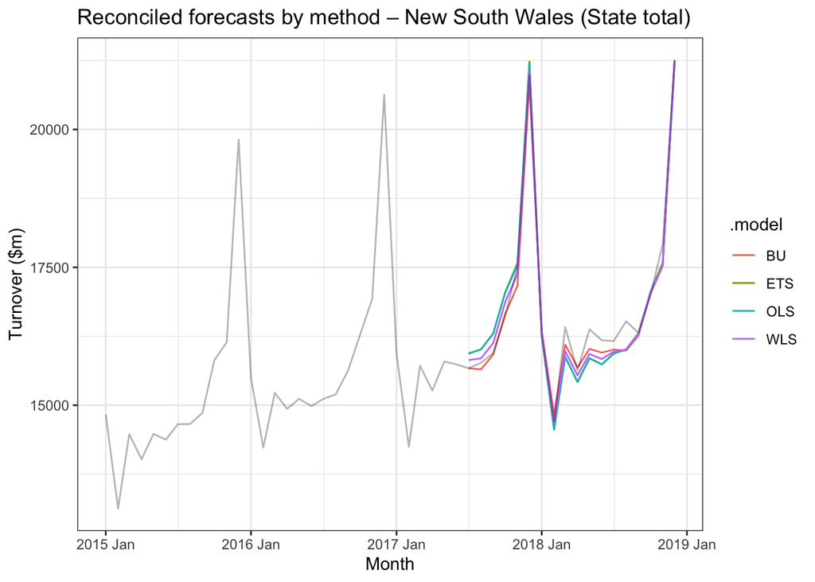

```r
nsw_hist = retail_hier %>%
  filter(State == "New South Wales", is_aggregated(Industry))

recon_nsw = recon_fc %>%
  filter(State == "New South Wales", is_aggregated(Industry))

autoplot(recon_nsw, level = NULL) +
  autolayer(nsw_hist, Turnover, alpha = 0.3) +
  labs(title = paste("Reconciled forecasts by method –", "New South Wales", "(State total)"),
       y = "Turnover ($m)") +
  theme_bw()
```